# projet_STA

BOUILLON Mathis

2024-12-12

# Projet de Séries Temporelles Avancées

### Modèle ARDL : une définition formelle

Le modèle ARDL (AutoRegressive Distributed Lag) est une spécification économétrique qui permet de modéliser la relation dynamique entre une variable dépendante $y_t$ et un ensemble de variables explicatives $x_{it}$.

La forme générale d’un modèle ARDL(p, q) peut s’écrire comme suit :

$$y_t = \alpha + \sum_{i=1}^p \phi_i y_{t-i} + \sum_{j=0}^q \sum_{i=1}^k
\beta_{ij} x_{i,t-j} + \varepsilon_t$$

où :

- $y_t$ est la variable dépendante à l’instant $t$,
- $x_{i,t-j}$ sont les variables explicatives (avec $i = 1, ..., k$ et $j = 0, ..., q$ pour capturer les décalages),
- $\alpha$ est la constante,
- $\phi_i$ sont les coefficients des termes autorégressifs,
- $\beta_{ij}$ sont les coefficients des termes à retards distribués,
- $\varepsilon_t$ est le terme d’erreur.

Ce modèle est utilisé pour analyser les relations à court terme et à long terme entre les variables. En cas de cointégration entre $y_t$ et $x_{it}$, une transformation du modèle ARDL en un modèle de correction d’erreur (ECM) permet de quantifier les ajustements vers l’équilibre de long terme.

p est l’ordre de l’AR, et q est le nombre de retards appliqué aux variables explicatives ou exogènes au modèle.

# Récupération des données du CAC 40 et visualisation :

```r
# Télécharger les données du CAC 40
cac40 <- getSymbols("^FCHI", src = "yahoo", from = "1990-01-01", to = "2023-12-31", auto.assign = FALSE)
```

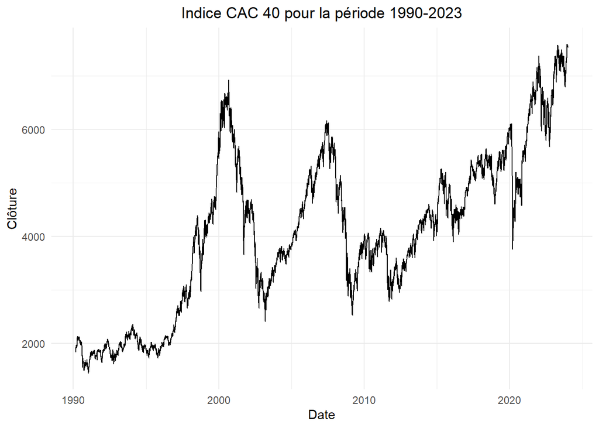

```r
# Extraire uniquement les prix de clôture
cac40_close <- na.omit(Cl(cac40))  # 'Cl()' extrait la colonne de clôture
#nous pouvons également considérer d'autres indicateurs tq le max sur la journée, le min...
colnames(cac40_close) <- "Close"

#Visualisation de la série

autoplot(cac40_close) +
  ggtitle("Indice CAC 40 pour la période 1990-2023") +
  xlab("Date") +
  ylab("Clôture") +
  theme_minimal() +
  theme(plot.title = element_text(hjust = 0.5))
```

# Analyse préliminaire de la série de l’indice

## Valeurs manquantes

```r
# Vérifier s'il y a des valeurs manquantes dans la série
missing_values <- sum(is.na(cac40_close))

# Afficher le nombre de valeurs manquantes
print(paste("Nombre de valeurs manquantes :", missing_values))
```

```
## [1] "Nombre de valeurs manquantes : 0"
```

```r
# Si des valeurs manquantes existent, afficher leurs dates
if (missing_values > 0) {
  missing_dates <- index(cac40_close)[is.na(cac40_close)]
  print("Dates avec valeurs manquantes :")
  print(missing_dates)
} else {
  print("Aucune valeur manquante dans la série.")
}
```

```
## [1] "Aucune valeur manquante dans la série."
```

La série ne présente pas de valeurs manquantes.

## Stat desc

```r
basicStats(cac40_close)
```

```
##                     Close
## nobs         8.590000e+03
## NAs          0.000000e+00
## Minimum      1.441000e+03
## Maximum      7.596910e+03
## 1. Quartile  3.002600e+03
## 3. Quartile  5.189972e+03
## Mean         4.094829e+03
## Median       4.122800e+03
## Sum          3.517458e+07
## SE Mean      1.621398e+01
## LCL Mean     4.063046e+03
## UCL Mean     4.126612e+03
## Variance     2.258251e+06
## Stdev        1.502748e+03
## Skewness     9.921800e-02
## Kurtosis    -7.846610e-01
```

## Observation de la tendance (linéaire)

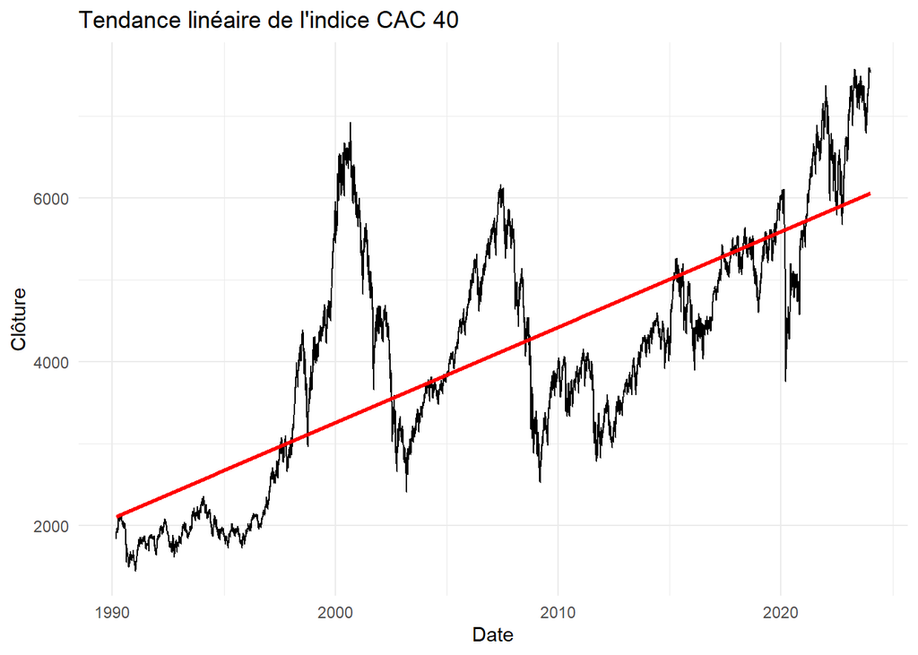

```r
#graphiquement

# Ajouter une tendance linéaire
autoplot(cac40_close) +
  geom_smooth(method = "lm", se = FALSE, color = "red") +
  ggtitle("Tendance linéaire de l'indice CAC 40") +
  xlab("Date") +
  ylab("Clôture") +
  theme_minimal()
```

```r
#avec le R**2

# Créer une variable temporelle
time <- as.numeric(index(cac40_close))

# Ajuster un modèle linéaire : Prix ~ Temps
lm_model <- lm(coredata(cac40_close) ~ time)

# Résumé du modèle
summary(lm_model)
```

```
##
## Call:
## lm(formula = coredata(cac40_close) ~ time)
##
## Residuals:
##     Min      1Q  Median      3Q     Max
## -1863.6  -683.0  -277.1   606.1  3586.8
##
## Coefficients:
##               Estimate Std. Error t value Pr(>|t|)
## (Intercept) -249.16433   41.68769  -5.977 2.36e-09 ***
## time           0.31995    0.00297 107.727  < 2e-16 ***
## ---
## Signif. codes:  0 '***' 0.001 '**' 0.01 '*' 0.05 '.' 0.1 ' ' 1
##
## Residual standard error: 980.1 on 8588 degrees of freedom
## Multiple R-squared:  0.5747, Adjusted R-squared:  0.5747
## F-statistic: 1.161e+04 on 1 and 8588 DF,  p-value: < 2.2e-16
```

## détection de la saisonnalité

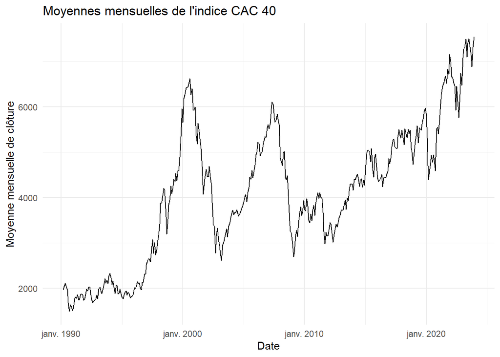

```r
# Convertir la série en périodicité mensuelle
cac40_monthly <- to.monthly(cac40_close, indexAt = "lastof", OHLC = FALSE)

# Visualisation des moyennes mensuelles
cac40_monthly_mean <- aggregate(cac40_monthly, as.yearmon, mean)

autoplot(cac40_monthly_mean) +
  ggtitle("Moyennes mensuelles de l'indice CAC 40") +
  xlab("Date") +
  ylab("Moyenne mensuelle de clôture") +
  theme_minimal()
```

## détection des outliers

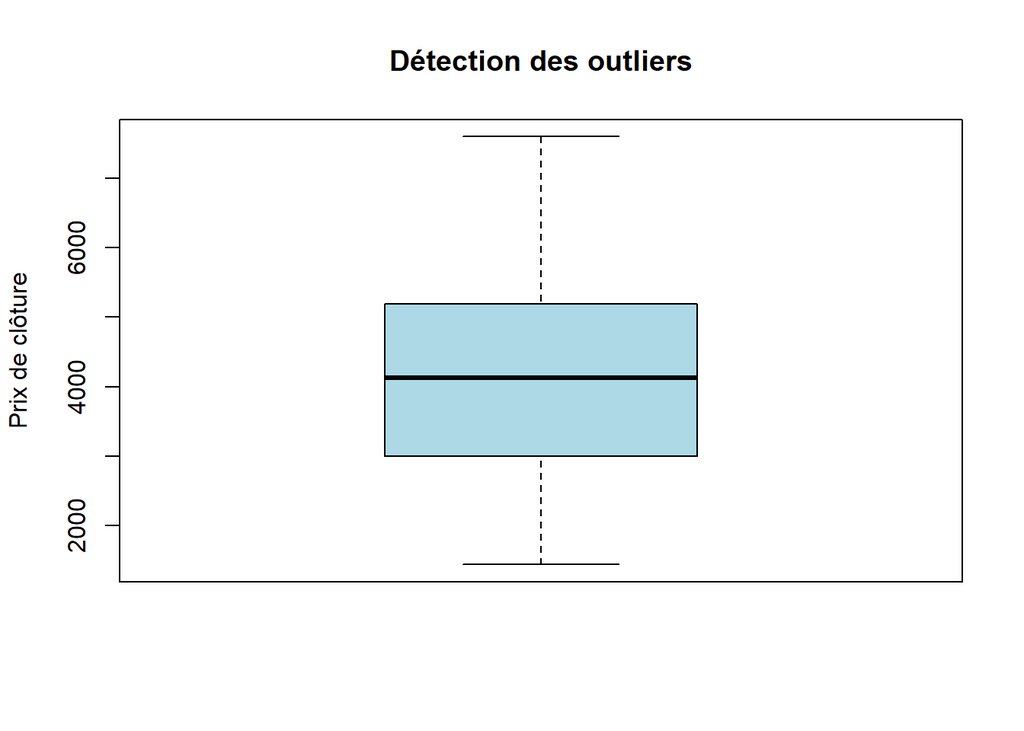

```r
# Détection visuelle avec boxplot
boxplot(coredata(cac40_close), main = "Détection des outliers",
        ylab = "Prix de clôture", col = "lightblue")
```

```r
# Repérer les outliers par quantile
q1 <- quantile(cac40_close, 0.25)
q3 <- quantile(cac40_close, 0.75)
iqr <- q3 - q1
outliers <- cac40_close[cac40_close < (q1 - 1.5 * iqr) | cac40_close > (q3 + 1.5 * iqr)]

print("Outliers détectés :")
```

```
## [1] "Outliers détectés :"
```

```r
print(outliers)
```

```
##      Close
```

Nous allons maintenant regarder les log returns de cette série (ce qui est équivalent à une première différenciation de la série) afin de voir si elle est stationnaire ou non

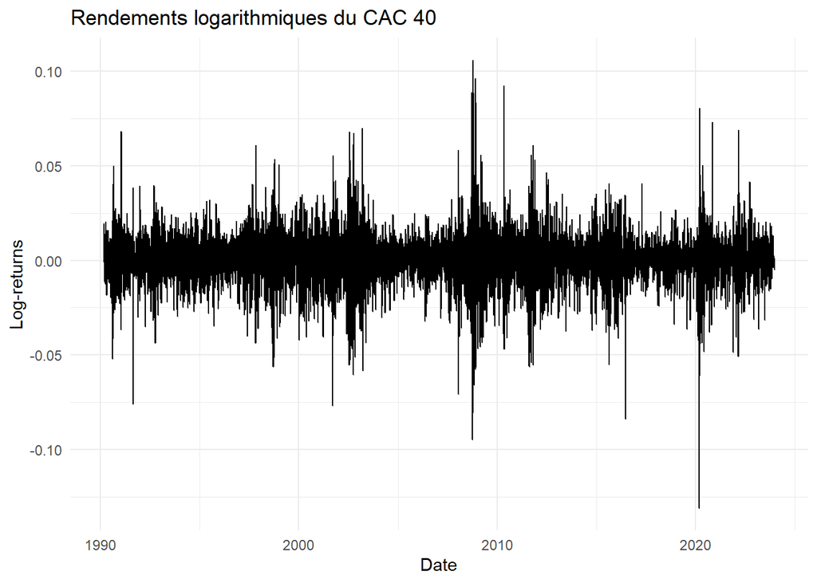

```r
# Calcul des rendements logarithmiques
log_returns <- diff(log(cac40_close))

# Visualisation des rendements
autoplot(log_returns) +
  ggtitle("Rendements logarithmiques du CAC 40") +
  xlab("Date") +
  ylab("Log-returns") +
  theme_minimal()
```

```r
# Statistiques descriptives des rendements
basicStats(log_returns)
```

```
##                   Close
## nobs        8590.000000
## NAs            1.000000
## Minimum       -0.130983
## Maximum        0.105946
## 1. Quartile   -0.006494
## 3. Quartile    0.007279
## Mean           0.000165
## Median         0.000440
## Sum            1.415236
## SE Mean        0.000146
## LCL Mean      -0.000122
## UCL Mean       0.000452
## Variance       0.000184
## Stdev          0.013570
## Skewness      -0.195928
## Kurtosis       5.798655
```

```
## Defaulting to continuous.
```

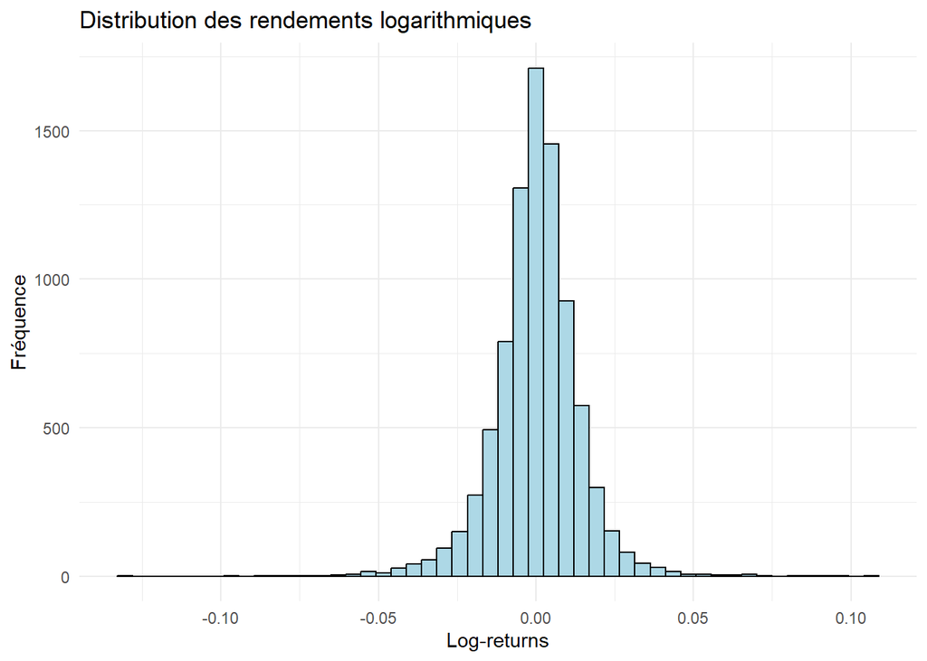

```r
# Histogramme des rendements
ggplot(data = data.frame(log_returns = coredata(log_returns)), aes(x = log_returns)) +
  geom_histogram(bins = 50, fill = "lightblue", color = "black") +
  ggtitle("Distribution des rendements logarithmiques") +
  xlab("Log-returns") +
  ylab("Fréquence") +
  theme_minimal()
```

On checke la stationnarité de la série avec un test de Dickey :

```r
# Test ADF sur les rendements logarithmiques
adf_test <- adf.test(na.omit(log_returns))
# Afficher les résultats du test
print(adf_test)
```

```
##
##  Augmented Dickey-Fuller Test
##
## data:  na.omit(log_returns)
## Dickey-Fuller = -20.783, Lag order = 20, p-value = 0.01
## alternative hypothesis: stationary
```

La série des rendements est bien stationnaire. Nous pouvons également le tester avec le test KPSS :

```r
# Test KPSS sur les rendements logarithmiques
kpss_test <- ur.kpss(na.omit(log_returns))

# Résumé des résultats
summary(kpss_test)
```

```
##
## #######################
## # KPSS Unit Root Test #
## #######################
##
## Test is of type: mu with 12 lags.
##
## Value of test-statistic is: 0.0543
##
## Critical value for a significance level of:
##                 10pct  5pct 2.5pct  1pct
## critical values 0.347 0.463  0.574 0.739
```

Le test-statistic obtenu (0.0543) est bien inférieur à toutes les valeurs critiques obtenues à pour chaque seuil. Cela signifie que nous ne rejetons pas l’hypothèse nulle i.e. que les rendements logarithmiques du CAC 40 sont stationnaires autour d’une moyenne constante.